#### 5. Plots

##### 5.1

다음 barplot과 이를 그리는 데 사용된 코드에서 barplot을 그리는 데 꼭 있어야 하는 코드는 무엇인가?

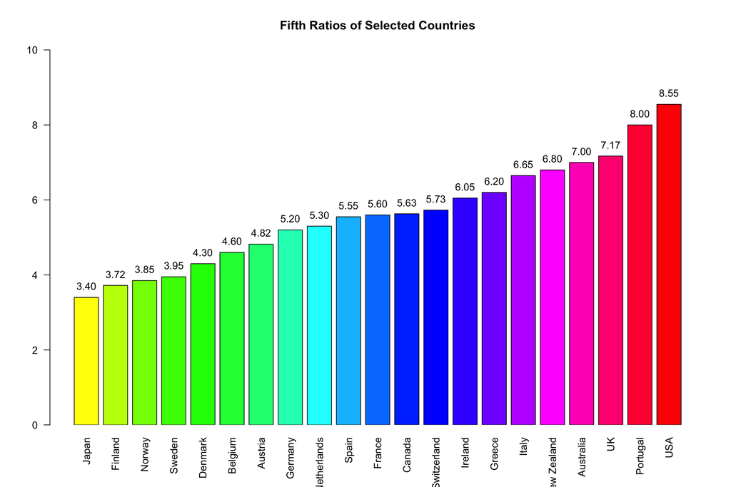

```r
fifth <- data.21$Income.inequality
Country <- data.21$Country
o.fifth <- order(fifth)
N <- nrow(data.21)
b.fifth <- barplot(fifth[o.fifth], names.arg = Country[o.fifth], col = rainbow(N, start = 1/6, end = 1), ylim = c(0, 10), xpd = FALSE, las = 2)
text(x = b.fifth, y = fifth[o.fifth] + 0.3, labels = format(fifth[o.fifth], digits = 3))
title(main = "Fifth Ratios of Selected Countries")
```

가. `fifth[o.fifth]`

나. `names.arg = Country[o.fifth]`

다. `col = rainbow(N, start = 1/6, end = 1)`

라. `ylim = c(0, 10)`

##### 5.2

위의 코드묶음에서 나라 이름을 막대 밑에 나오게 하는 역할을 수행하는 코드는 무엇인가?

가. `fifth[o.fifth]`

나. `names.arg = Country[o.fifth]`

다. `col = rainbow(N, start = 1/6, end = 1)`

라. `ylim = c(0, 10)`

##### 5.3

위의 코드묶음에서 막대의 색깔을 정하는 역할을 수행하는 코드는 무엇인가?

가. `fifth[o.fifth]`

나. `names.arg = Country[o.fifth]`

다. `col = rainbow(N, start = 1/6, end = 1)`

라. `ylim = c(0, 10)`

##### 5.4

위의 코드묶음에서 막대 안쪽으로 소득5분위계수를 써 주려면 `text(...)` 안에서 어떤 코드를 바꿔야 하는가?

가. `x = b.fifth`

나. `y = fifth[o.fifth] + 0.3`

다. `labels = format(fifth[o.fifth], digits = 3)`

라. `digits = 3`

#### Scatter Diagram

##### 5.5

다음 산점도와 이 산점도를 그리는 데 사용된 코드묶음에서 점의 색깔을 정하는 코드는 무엇인가?

가. `pch = 20`

나. `col = "red"`

다. `xlim = c(3, 9), ylim = c(-1.5, 2.5)`

라. `ann = FALSE`

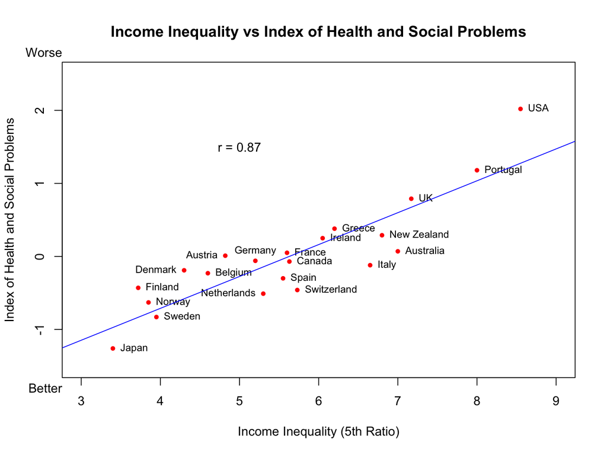

```r
Index_inequality.df <- data.21[c("Income.inequality", "Index.HS")]
cor.1 <- cor(data.21["Income.inequality"], data.21["Index.HS"])
Country <- data.21[, "Country"]
text.left <- which(Country %in% c("Austria", "Denmark", "Germany", "Netherlands"))
text.right <- setdiff(1:nrow(data.21), text.left)
pos.text <- ifelse(1:nrow(data.21) %in% text.left, 2, 4)
text.up <- which(Country %in% "Germany")
text.left <- setdiff(1:nrow(data.21), c(text.right, text.up))
pos.text <- ifelse(1:nrow(data.21) %in% text.up, 3, ifelse(1:nrow(data.21) %in% text.left, 2, 4))
plot(Index_inequality.df, pch = 20, col = "red", xlim = c(3, 9), ylim = c(-1.5, 2.5), ann = FALSE)
text(Index_inequality.df, labels = Country, pos = pos.text, cex = 0.8)
main.title <- "Income Inequality vs Index of Health and Social Problems"
x.lab <- "Income Inequality (5th Ratio)"
y.lab <- "Index of Health and Social Problems"
title(main = main.title, xlab = x.lab, ylab = y.lab)
mtext(c("Better", "Worse"), side = 2, at = c(-1.8, 2.8), las = 1)
text(x = 5, y = 1.5, labels = paste("r =", round(cor.1, digits = 2)))
lm.ineq <- lm(Index.HS ~ Income.inequality, data = Index_inequality.df)
# lm.ineq <- lm(Index_inequality.df[2:1])
abline(lm.ineq$coef, col = "blue")
```

##### 5.6

위의 코드묶음에서 점의 모양을 정하는 코드는 무엇인가?

가. `pch = 20`

나. `col = "red"`

다. `xlim = c(3, 9), ylim = c(-1.5, 2.5)`

라. `ann = FALSE`

##### 5.7

위의 그림에서 `Germany`의 경우 `pos =`이 얼마로 부여되었는가?

가. `1`

나. `2`

다. `3`

라. `4`

##### 5.8

위의 그림에서 상관계수 정보를 소숫점 2자리로 줄인 역할은 어떤 코드가 수행하는가?

가. `x = 5, y = 1.5`

나. `labels = paste("r =",`

다. `round(cor.1, digits = 2))`

라. `digits = 2`